# 2 age-stratified ODE

Stefan Scholz

2022-09-13

### Background

The outbreak investigation continues and more data becomes available, especially with regard to different age groups. The outbreak looked at the age groups **0 to 17 years**, **18 to 34 years**, **35 to 59 years** and **60 years and older**. The age-distribution of the passengers is representative for the German general population. The analysis of the outbreak data reveals the number of initially infected passengers in each age group and different durations of being infectious. The data is displayed in the table below.

| Agegroup | Passengers | Index patients | Duration of infectiousness |
| --- | --- | --- | --- |
| 0 to 17 | 518 | 2 | 2 days |
| 18 to 34 | 538 | 1 | 3 days |
| 35 to 59 | 891 | 3 | 3 days |
| 60 plus | 552 | 4 | 5 days |

A contact survey on the social contacts reveals that the contact behavior is similar to the contact behavior outside a cruise ship.

### Mandatory Tasks

- Go to the [Socrates database](http://www.socialcontactdata.org/socrates/) and generate and download a contact matrix for the above mentioned age groups using pre-pandemic data from Germany (all types of contacts, all weekdays, all durations of contacts).
- Take the SIRS-model from the last exercise and try to include age-stratification for 4 age groups. Specifically,
  - Extend the equations
  - Adjust the input
  - Adjust the *run.ode* and *plot.ode* functions to allow looking at age groups and compartments separately

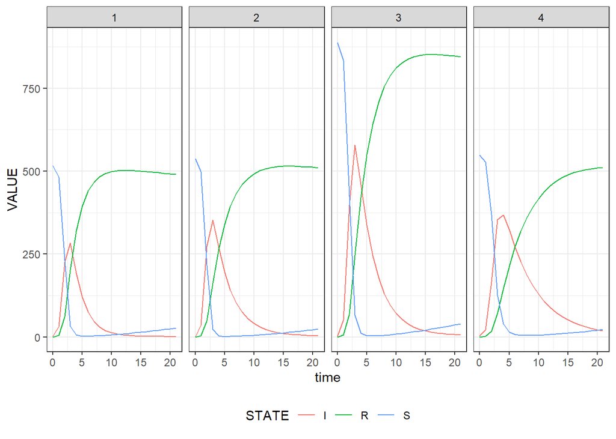

```r
library(tidyverse)
library(deSolve)

sirs <- function(time, state, parms) {
  # calculate number of populaton size from compartments
  N <- state[1:4] + state[5:8] + state[9:12]
  # calculate the number of new infections
  flow.I <- (state[1:4] * parms[["beta"]]) * (parms[["contacts"]] %*% (state[5:8]/N))
  # Increment the number of persons in each compartment
  dS <- -flow.I                               + parms[["sigma"]] * state[9:12]
  dI <-  flow.I - parms[["gamma"]] * state[5:8]
  dR <-         + parms[["gamma"]] * state[5:8] - parms[["sigma"]] * state[9:12]
  # return result
  return(list(c(dS, dI, dR, flow.I)))
}

run.ode <- function(times, inits, parms, ode.func) {
  out.ode <- lsoda(y = inits, times = times, func = ode.func, parms = parms) %>%
    as.data.frame() %>% pivot_longer(names_to = "STATE", values_to = "VALUE", !1) %>%
    mutate(AGE = str_extract(STATE, "[:digit:]"), STATE = str_extract(STATE, "[:alpha:]"))
  return(out.ode)
}

plot.ode <- function(df) {
  df <- df %>% filter(str_detect(STATE, "f") == F)

  p <- ggplot(df)
  p <- p + geom_line(aes(x=time, y = VALUE, color=STATE))
  p <- p + facet_grid(.~AGE)
  p <- p + theme_bw() + theme(legend.position = "bottom")
  p
}

inits <- c(S = c(516, 537, 888, 548), I = c(2, 1, 3, 4), R = c(0, 0, 0, 0), flow.I = c(0, 0, 0, 0))
times <- 0:21
contacts <- read.csv("../1_input/social_contact_matrix.csv")
parms <- list(gamma = c(1/2, 1/3, 1/3, 1/5),
              sigma = 1/180,
              beta = 0.4,
              contacts = as.matrix(contacts))

res.sirs <- run.ode(times = times, inits = inits, parms = parms, ode.func = sirs)

plot.ode(res.sirs)
```

- Try to run the model and plot the results for the above mentioned age groups.
- Try to construct a contact matrix that doesn’t allow for transmission between age groups. Check by putting the initially infected in only one age group.

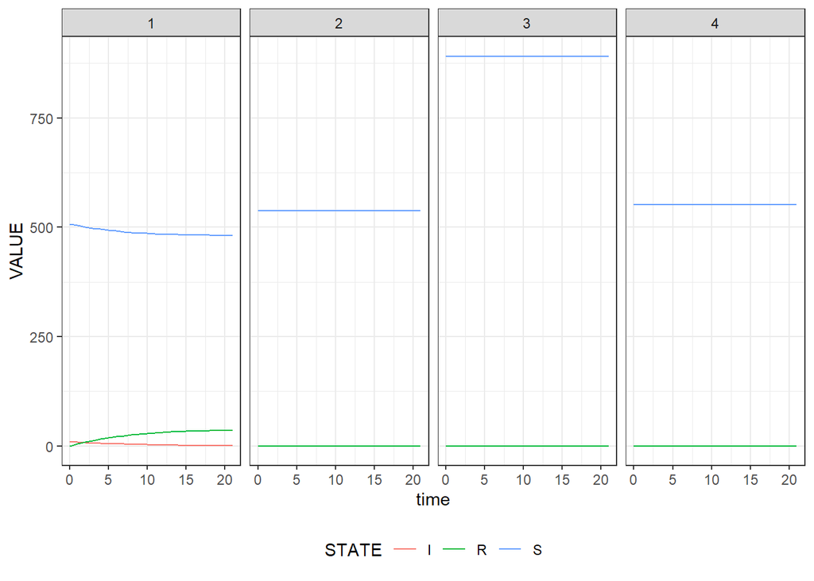

```r
inits <- c(S = c(508, 538, 891, 552), I = c(10, 0, 0, 0), R = c(0, 0, 0, 0), flow.I = c(0, 0, 0, 0))

contacts <- matrix(0, ncol = 4, nrow = 4)
diag(contacts) <- 1
parms <- list(gamma = c(1/2, 1/3, 1/3, 1/5),
              sigma = 1/180,
              beta = 0.4,
              contacts = contacts)


res.sirs <- run.ode(times = times, inits = inits, parms = parms, ode.func = sirs)

plot.ode(res.sirs)
```

- Have a look at the original data (you can download the file [here](https://zenodo.org/record/3746312#.YxdU26HP1D9)).
  - How reliable do you think is the data across different age groups?
  - How does the German data compare against data from other countries?

### Advanced Tasks

#### Age-specific rates

In the above example, younger people tend to have a shorter duration of infectiousness.

- Given the same duration of infectiousness, how could you incorporate different, age-specific levels of infectiousness (e.g., infecting somebody)?
- On the contrary, how could you achieve different, age-specific levels of susceptibility (i.e., getting infected)?

#### Setting-specific contacts

During the COVID-19 pandemic contact behavior changed differently in different contact settings (e.g., at-home, school, etc.).

- Try to include contacts in different settings into the model.
- Try to incorporate different levels of infectiousness for each setting in the model.